# Exploratory Route-3 Synthetic Cortical-Rate NPE Ensemble

Three independently initialized, single-round conditional density estimators are trained on the same fixed 1,638/410 split. The proposal is the frozen prior; there are no sequential rounds. The result is always called an **exploratory Route-3 synthetic cortical-rate posterior**, never an EEG posterior.

```python
from __future__ import annotations
import json
import os
from pathlib import Path
import sys

import matplotlib.pyplot as plt
import numpy as np
import pandas as pd

PROJECT_ROOT = Path.cwd().resolve()
if not (PROJECT_ROOT / "S4_sbi" / "src").exists():
    for parent in PROJECT_ROOT.parents:
        if (parent / "S4_sbi" / "src").exists():
            PROJECT_ROOT = parent
            break
for path in (PROJECT_ROOT / "S4_sbi" / "src", PROJECT_ROOT):
    if str(path) not in sys.path:
        sys.path.insert(0, str(path))

from sleep_sbi.route3_global_robustness import RESULTS_ROOT, rate_feature_names
from sleep_sbi.route3_pilot_snpe import (
    ARCHITECTURE,
    MODEL_SEEDS,
    TRAINING_POLICY,
    TRAINING_ROOT,
    exploratory_member_checks,
    load_ensemble_members,
    sample_equal_ensemble_normalized,
    train_ensemble,
    write_go_criteria,
)
from sleep_sbi.route3_synthetic_preflight import PARAMETER_NAMES

BANK_ROOT = RESULTS_ROOT / "simulation_bank_2048"
FIGURE_DIR = TRAINING_ROOT / "figures"
FIGURE_DIR.mkdir(parents=True, exist_ok=True)
assert Path(sys.prefix).name.lower() == "neurolib"
print("Environment:", os.environ.get("CONDA_DEFAULT_ENV"))
print("Python:", sys.executable)
```

```
Environment: neurolib
Python: C:\Users\YUS190\AppData\Local\anaconda3\envs\neurolib\python.exe
```

## 1. Frozen training protocol

- MAF conditional density estimator, 64 hidden features, five transforms;
- explicit train-only x median/IQR scaling and normalized prior coordinates;
- batch size 128, Adam learning rate 5e-4, gradient clipping 5;
- best-validation checkpoint plus resumable last checkpoint;
- maximum 300 epochs, early-stopping patience 25;
- seeds 1301, 1302, 1303;
- equal ensemble weights, with no weighting fitted on held-out results.

```python
training = train_ensemble(
    BANK_ROOT / "route3_cortex_rate_14d_bank_2048.npz",
    BANK_ROOT / "split_and_scaling.npz",
)
data = training["data"]
summary = training["summary"]
members = load_ensemble_members(data)
training_audit = json.loads(
    (TRAINING_ROOT / "training_execution_audit.json").read_text(encoding="utf-8")
)
member_frame = pd.DataFrame(summary["members"])
member_frame["initial_training_runtime_s"] = member_frame["seed"].astype(str).map(
    training_audit["member_runtime_s"]
)
display(
    member_frame[
        [
            "seed", "device", "epochs_completed", "best_epoch",
            "best_validation_loss", "final_train_loss",
            "final_validation_loss", "initial_training_runtime_s",
        ]
    ]
)
print("Initial ensemble training stage runtime (s):", training_audit["ensemble_stage_runtime_s"])
display(pd.DataFrame([{"architecture": ARCHITECTURE, "policy": TRAINING_POLICY}]))
assert len(members) == 3
```

|  | seed | device | epochs_completed | best_epoch | best_validation_loss | final_train_loss | final_validation_loss | initial_training_runtime_s |
| --- | --- | --- | --- | --- | --- | --- | --- | --- |
| 0 | 1301 | cpu | 300 | 294 | -8.498206 | -9.168434 | -8.276238 | 48.020417 |
| 1 | 1302 | cpu | 294 | 267 | -8.561801 | -9.170785 | -8.478744 | 46.745328 |
| 2 | 1303 | cpu | 300 | 295 | -8.237808 | -8.697614 | -8.139855 | 47.018407 |

```
Initial ensemble training stage runtime (s): 144.02194840006996
```

|  | architecture | policy |
| --- | --- | --- |
| 0 | {'model': 'maf', 'hidden_features': 64, 'num_t... | {'batch_size': 128, 'learning_rate': 0.0005, '... |

## 2. Training and validation loss

Negative loss values are valid log-density objectives. Model selection uses only the fixed validation split. Differences between member curves reflect initialization and minibatch order, not different simulation data.

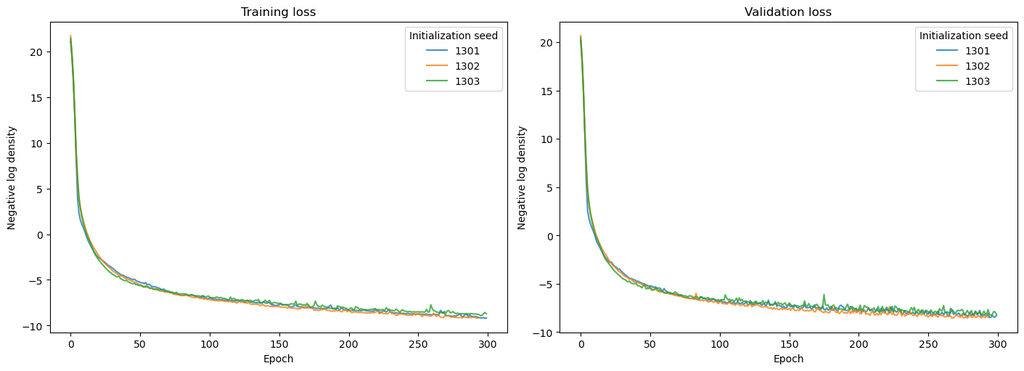

```python
fig, axes = plt.subplots(1, 2, figsize=(14, 5), constrained_layout=True)
for seed in MODEL_SEEDS:
    history = pd.read_csv(TRAINING_ROOT / f"member_{seed}" / "training_history.csv")
    axes[0].plot(history.epoch, history.train_loss, label=str(seed), alpha=.8)
    axes[1].plot(history.epoch, history.validation_loss, label=str(seed), alpha=.8)
axes[0].set(xlabel="Epoch", ylabel="Negative log density", title="Training loss")
axes[1].set(xlabel="Epoch", ylabel="Negative log density", title="Validation loss")
axes[0].legend(title="Initialization seed")
axes[1].legend(title="Initialization seed")
fig.savefig(FIGURE_DIR / "ensemble_training_curves.png", dpi=180)
fig.savefig(FIGURE_DIR / "ensemble_training_curves.svg")
plt.show()
```

## 3. Pre-held-out member checks

Thirty-two positions from the internal validation split are used only for engineering checks: finite samples, prior support, boundary accumulation, posterior dispersion, and member disagreement. These are not the independent 128-case scientific held-out set.

```python
checks = exploratory_member_checks(data, members)
checks.to_csv(TRAINING_ROOT / "member_checks.csv", index=False)
member_summary = checks.groupby("member").agg(
    finite_rate=("finite_rate", "mean"),
    in_prior_rate=("within_prior_rate", "mean"),
    median_error=("mean_normalized_median_error", "mean"),
    boundary_fraction=("boundary_sample_fraction", "mean"),
    posterior_std=("mean_posterior_std", "mean"),
)
display(member_summary)
assert (member_summary.finite_rate == 1).all()
assert (member_summary.in_prior_rate == 1).all()
```

| member | finite_rate | in_prior_rate | median_error | boundary_fraction | posterior_std |
| --- | --- | --- | --- | --- | --- |
| 0 | 1.0 | 1.0 | 0.124682 | 0.099365 | 0.134942 |
| 1 | 1.0 | 1.0 | 0.127169 | 0.111664 | 0.138591 |
| 2 | 1.0 | 1.0 | 0.133969 | 0.117676 | 0.139564 |

## 4. Transparent equal-mixture sampling

For any observation, requested samples are divided as evenly as possible among the three members, concatenated, and shuffled with a recorded seed. No member receives a data-dependent weight.

|  | member | samples | weight |
| --- | --- | --- | --- |
| 0 | 0 | 1366 | 0.333496 |
| 1 | 1 | 1365 | 0.333252 |
| 2 | 2 | 1365 | 0.333252 |

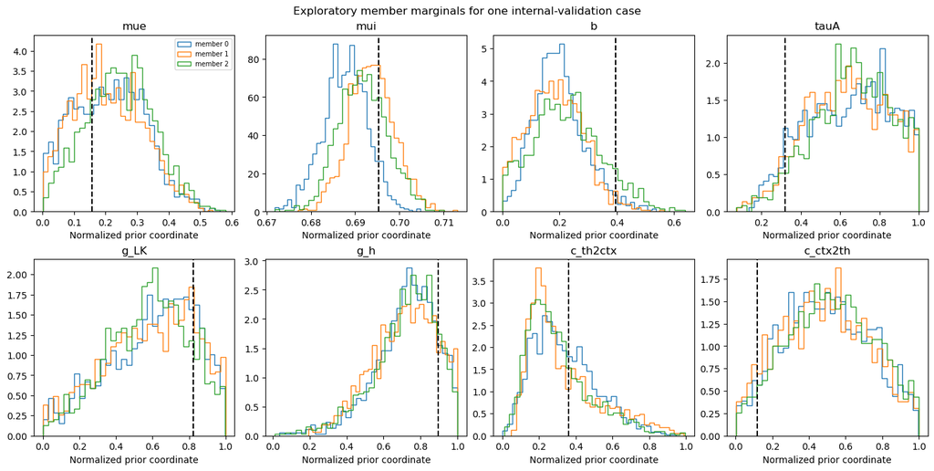

```python
case_index = len(data.x_validation) // 2
samples, labels = sample_equal_ensemble_normalized(
    members, data.x_validation[case_index], 4096, seed=20260801
)
assert samples.shape == (4096, 8)
assert np.isfinite(samples).all()
assert ((samples >= 0) & (samples <= 1)).all()
mixture_counts = pd.Series(labels).value_counts().sort_index()
display(pd.DataFrame({"member": range(3), "samples": mixture_counts.values, "weight": mixture_counts.values / 4096}))

fig, axes = plt.subplots(2, 4, figsize=(14, 7), constrained_layout=True)
for parameter_index, ax in enumerate(axes.flat):
    for member_index in range(3):
        ax.hist(samples[labels == member_index, parameter_index], bins=35, histtype="step", density=True, label=f"member {member_index}")
    ax.axvline(data.theta_validation[case_index, parameter_index], color="black", ls="--")
    ax.set(title=PARAMETER_NAMES[parameter_index], xlabel="Normalized prior coordinate")
axes[0,0].legend(fontsize=7)
fig.suptitle("Exploratory member marginals for one internal-validation case")
fig.savefig(FIGURE_DIR / "representative_member_marginals.png", dpi=180)
fig.savefig(FIGURE_DIR / "representative_member_marginals.svg")
plt.show()
```

## 5. Ridge and boundary screening

The `g_LK/g_h` and bidirectional-coupling panels screen for the confounds observed in Notebooks 10-12. A visible ridge is not automatically failure if uncertainty and coverage are honest; a falsely narrow ridge is.

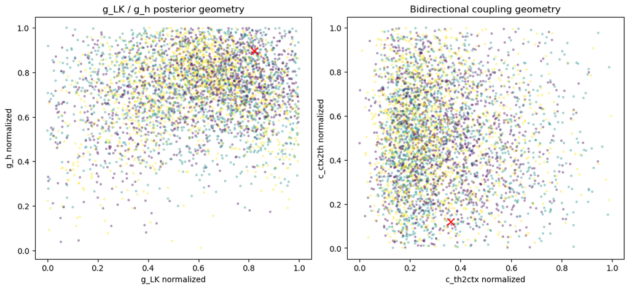

```python
fig, axes = plt.subplots(1, 2, figsize=(11, 5), constrained_layout=True)
axes[0].scatter(samples[:, 4], samples[:, 5], c=labels, s=5, alpha=.3, cmap="viridis")
axes[0].scatter(data.theta_validation[case_index, 4], data.theta_validation[case_index, 5], c="red", marker="x", s=80)
axes[0].set(xlabel="g_LK normalized", ylabel="g_h normalized", title="g_LK / g_h posterior geometry")
axes[1].scatter(samples[:, 6], samples[:, 7], c=labels, s=5, alpha=.3, cmap="viridis")
axes[1].scatter(data.theta_validation[case_index, 6], data.theta_validation[case_index, 7], c="red", marker="x", s=80)
axes[1].set(xlabel="c_th2ctx normalized", ylabel="c_ctx2th normalized", title="Bidirectional coupling geometry")
fig.savefig(FIGURE_DIR / "representative_ridges.png", dpi=180)
fig.savefig(FIGURE_DIR / "representative_ridges.svg")
plt.show()
```

## 6. GO criteria freeze

The operational GO/CONDITIONAL-GO/NO-GO thresholds are written before any independent held-out theta is generated or opened. Subsequent notebooks may evaluate but must not rewrite this artifact.

```python
criteria_path = RESULTS_ROOT / "heldout_validation" / "go_criteria_frozen.json"
criteria = write_go_criteria(criteria_path)
display(pd.DataFrame(criteria["formal_go"].items(), columns=["formal GO criterion", "frozen value"]))
print("Criteria path:", criteria_path)
```

|  | formal GO criterion | frozen value |
| --- | --- | --- |
| 0 | training_failure_rate_max | 0.01 |
| 1 | heldout_failure_rate_max | 0.01 |
| 2 | posterior_finite_and_in_prior_rate_min | 0.999 |
| 3 | coverage_80_or_90_wilson_contains_nominal_para... | 7 |
| 4 | severe_undercoverage_definition | observed coverage < nominal-0.15 and Wilson up... |
| 5 | severe_undercoverage_parameters_max | 0 |
| 6 | median_error_better_than_prior_parameters_min | 6 |
| 7 | overall_median_error_improvement_min_fraction | 0.1 |
| 8 | meaningful_contraction_definition | median 90% CI width < 0.90 prior width |
| 9 | meaningful_contraction_with_reasonable_coverag... | 6 |
| 10 | ppc_features_better_than_prior_min | 10 |
| 11 | overall_ppc_error_improvement_min_fraction | 0.1 |
| 12 | ensemble_member_median_disagreement_mean_max_p... | 0.1 |
| 13 | ensemble_member_disagreement_parameter_max_pri... | 0.2 |
| 14 | global_collision_requirement | coverage/contraction must remain honest despit... |

```
Criteria path: D:\Year3_Mao_Projects\sleep_loop\S4_sbi\results\route3_pilot_snpe\heldout_validation\go_criteria_frozen.json
```

## Conclusion

All three models trained and return finite prior-supported samples. This is an engineering prerequisite, not scientific validation. Independent held-out recovery, nominal coverage, SBC, ensemble disagreement, and new-seed synthetic PPC determine the formal decision.